# Inequality and homicide, in 46 countries

after Prof. Dr. Walter Fuchs

Five variables for 46 countries — OECD plus selected others — and one question that is easy to ask and hard to answer: does inequality cause murder?

Every chunk below runs on its own. Work down them once, then go back and change one thing.

## 1 · The data

Semicolon-separated with comma decimals — a German-locale export, so `read.csv2`, not `read.csv`. The first column is the country name and becomes the row name, which is what lets you label points later.

```r
murderdat <- read.csv2("inputs/murder.csv", encoding = "UTF-8",
                       header = TRUE, row.names = 1)
str(murderdat)
```

```
## 'data.frame':    46 obs. of  5 variables:
##  $ murder    : num  3.94 0.943 0.987 1.1 18.691 ...
##  $ gini      : num  42.4 33.8 31.2 26.8 50.3 39.5 31.5 43 36 45.5 ...
##  $ infantmort: num  9.7 3.7 3.3 3.7 14.4 5.9 5.4 6.9 6.1 10.1 ...
##  $ social    : num  17 18.1 30.1 29.6 21.5 21.3 21 12.5 10.8 12.4 ...
##  $ unemploy  : num  16.87 9.27 10.73 17.65 15.64 ...
```

| variable | meaning |
| --- | --- |
| `murder` | homicide victims per 100,000 — UNODC |
| `gini` | Gini coefficient — World Bank |
| `infantmort` | under-5 mortality per 1,000 live births — World Bank |
| `social` | social protection spending, % of GDP — ILO |
| `unemploy` | male youth unemployment, % — World Bank / ILO |

## 2 · Look before you model

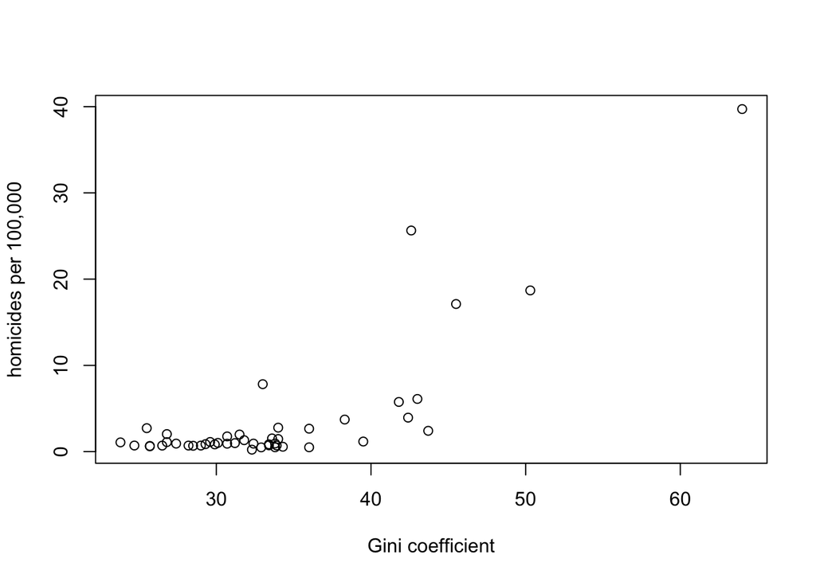

```r
plot(murderdat$gini, murderdat$murder,
     xlab = "Gini coefficient", ylab = "homicides per 100,000")
```

Not much of a linear relationship, is it?

```r
cor(murderdat$gini, murderdat$murder)
```

```
## [1] 0.7977956
```

And yet the correlation is high. A few countries are doing nearly all the work.

## 3 · The same data, on log axes

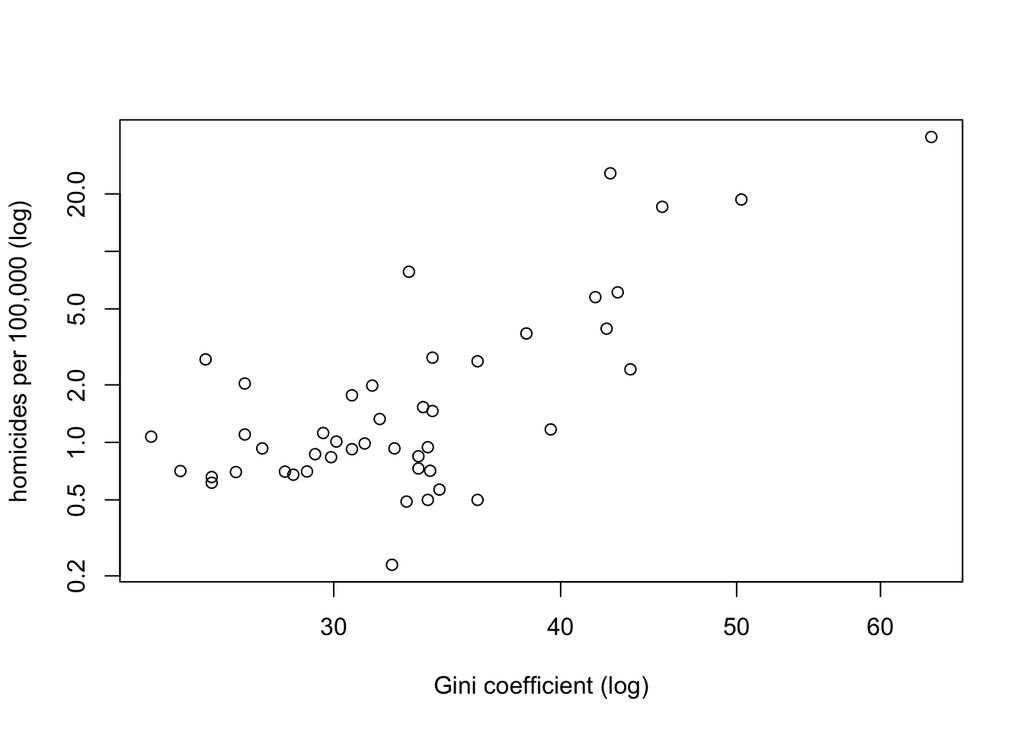

```r
plot(murderdat$gini, murderdat$murder, log = "xy",
     xlab = "Gini coefficient (log)", ylab = "homicides per 100,000 (log)")
```

```r
cor(log(murderdat$gini), log(murderdat$murder))
```

```
## [1] 0.7131051
```

**Nothing was added and nothing was removed.** Both plots are the same 46 numbers. This is the whole exercise in one step: you have not lied, and you have changed what a reader concludes.

Whether the log transform is *right* here is a real question with a real answer — both variables are strictly positive and strongly skewed, which is the textbook case for it. That is what makes it usable. A move nobody can object to is worth more than one they can.

## 4 · Which countries are carrying it

`identify()` is interactive and does nothing when a script runs unattended, so label the extremes directly instead.

```r
extreme <- murderdat[rank(-murderdat$murder) <= 5 | rank(murderdat$murder) <= 5, ]
extreme[order(-extreme$murder), c("murder", "gini")]
```

```
##                  murder gini
## South Africa 39.7189775 64.0
## Mexico       25.6378892 42.6
## Brazil       18.6911635 50.3
## Costa Rica   17.1153100 45.5
## Russia        7.8214107 33.0
## Italy         0.5662012 34.3
## China         0.5000000 36.0
## Switzerland   0.5000000 33.8
## Korea         0.4900000 32.9
## Japan         0.2286812 32.3
```

## 5 · The other three variables

Poverty, welfare and unemployment. Same treatment, so the comparison is fair.

```r
for (v in c("infantmort", "social", "unemploy")) {
  cat("\n", v, ": r = ", round(cor(murderdat[[v]], murderdat$murder), 3),
      "   log r = ", round(cor(log(murderdat[[v]]), log(murderdat$murder)), 3), "\n", sep = "")
}
```

```
##
## infantmort: r = 0.742   log r = 0.682
##
## social: r = -0.434   log r = -0.454
##
## unemploy: r = 0.498   log r = 0.224
```

Notice that they do not disagree with each other much. That is the problem waiting in section 7.

## 6 · Everything on one scale

Log, then standardise, so the regression coefficients can be compared with each other.

```r
L <- data.frame(
  murder     = scale(log(murderdat$murder)),
  gini       = scale(log(murderdat$gini)),
  infantmort = scale(log(murderdat$infantmort)),
  social     = scale(log(murderdat$social)),
  unemploy   = scale(log(murderdat$unemploy))
)
round(cor(L), 2)
```

```
##            murder  gini infantmort social unemploy
## murder       1.00  0.71       0.68  -0.45     0.22
## gini         0.71  1.00       0.57  -0.35     0.23
## infantmort   0.68  0.57       1.00  -0.69     0.30
## social      -0.45 -0.35      -0.69   1.00    -0.05
## unemploy     0.22  0.23       0.30  -0.05     1.00
```

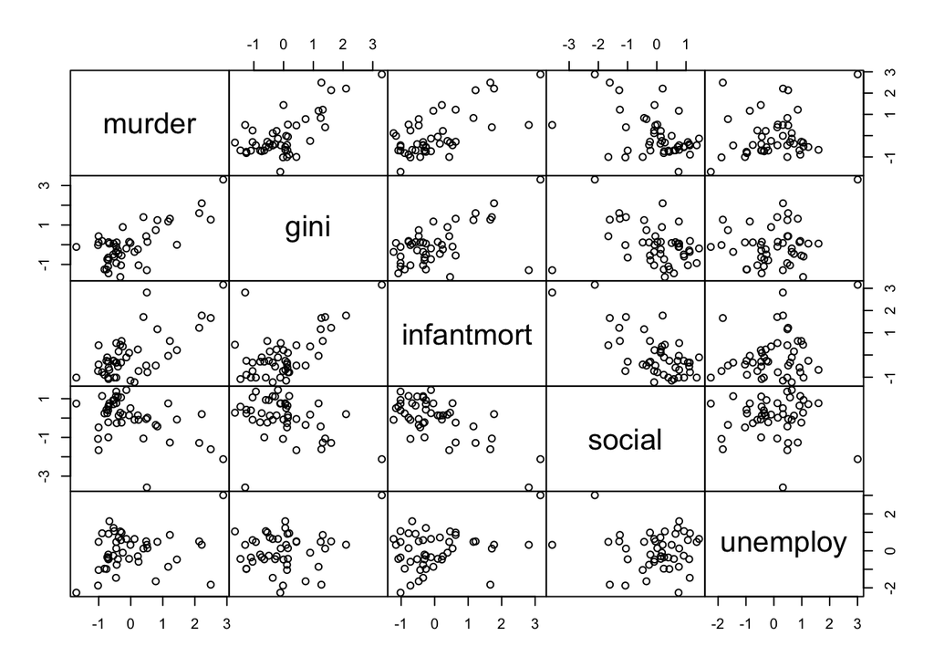

```r
plot(L, gap = 0)
```

## 7 · The model

```r
mod <- lm(murder ~ gini + infantmort + social + unemploy, data = L)
summary(mod)
```

```
##
## Call:
## lm(formula = murder ~ gini + infantmort + social + unemploy,
##     data = L)
##
## Residuals:
##      Min       1Q   Median       3Q      Max
## -1.39678 -0.35792 -0.04381  0.42428  1.34941
##
## Coefficients:
##               Estimate Std. Error t value Pr(>|t|)
## (Intercept)  5.788e-16  9.509e-02   0.000 1.000000
## gini         4.814e-01  1.176e-01   4.094 0.000194 ***
## infantmort   4.044e-01  1.597e-01   2.533 0.015246 *
## social      -8.534e-03  1.365e-01  -0.063 0.950456
## unemploy    -8.982e-03  1.040e-01  -0.086 0.931565
## ---
## Signif. codes:  0 '***' 0.001 '**' 0.01 '*' 0.05 '.' 0.1 ' ' 1
##
## Residual standard error: 0.6449 on 41 degrees of freedom
## Multiple R-squared:  0.621,  Adjusted R-squared:  0.5841
## F-statistic:  16.8 on 4 and 41 DF,  p-value: 3.155e-08
```

Read the coefficient table before you read the R². Four predictors that measure overlapping things will share the credit between them in ways that move when you drop one — so the honest question is not “is the model significant” but “which of these four would survive on its own, and does the answer depend on which others are in the room”.

```r
for (v in c("gini", "infantmort", "social", "unemploy")) {
  f <- summary(lm(as.formula(paste("murder ~", v)), data = L))
  cat(sprintf("%-11s beta = %6.3f   R2 = %.3f   p = %.2g\n",
              v, coef(f)[2, 1], f$r.squared, coef(f)[2, 4]))
}
```

```
## gini        beta =  0.713   R2 = 0.509   p = 2.7e-08
## infantmort  beta =  0.682   R2 = 0.465   p = 1.8e-07
## social      beta = -0.454   R2 = 0.206   p = 0.0015
## unemploy    beta =  0.224   R2 = 0.050   p = 0.13
```

## 8 · What to do next

Pick one and change it. Each of these is defensible, each changes the answer, and each is something the other team can find in your record:

- drop the three countries with the highest homicide rates and re-run section 7;
- take `gini` out of the model and see what `infantmort` does;
- do it all without the log transform;
- split the 46 into OECD and non-OECD and fit each separately.

Whatever you keep, the figure you show is the argument you are making. Choose it on purpose.